# Reproducible Research: Peer Assessment 1

This assignment makes use of data from a personal activity monitoring device. This device collects data at 5 minute intervals through out the day. The data consists of two months of data from an anonymous individual collected during the months of October and November, 2012 and include the number of steps taken in 5 minute intervals each day.

##Loading and preprocessing the data

The first step is to download, unpack and read the data.

```r
if(!file.exists("activity.zip")) {download.file("https://d396qusza40orc.cloudfront.net/repdata%2Fdata%2Factivity.zip", "activity.zip", method = "curl")}
if(!file.exists("activity.csv")) {unzip("activity.zip", exdir = "./")}
activity_raw <- read.csv("./activity.csv",
                         header = TRUE,
                         stringsAsFactors = FALSE,
                         na.strings = "NA",
                         colClasses = c("integer", "character", "integer"))
```

The data is processed in order to create a variable with date and time of the mesurements. We also load the package *lubridate*.

```r
library(lubridate)
activity <- data.frame(steps = activity_raw$steps)
#modify format to convert to date format
activity$interval <- formatC(activity_raw$interval, width = 4, flag = "0")
activity$interval <- paste(substr(activity$interval, 1, 2), substr(activity$interval, 3, 4), "00", sep = ":")
activity$date.time <- paste(activity_raw$date, activity$interval)
#convert to date format with lubridate
activity$date.time <- ymd_hms(activity$date.time)
```

##What is mean total number of steps taken per day?

For this question missing values are ignored. The first chunk of the code calculate the total number of steps taken per day.

```r
activity1 <- activity[!is.na(activity$steps), ]#remove missing values
activity1$date <- as.Date(activity1$date.time)#strip the time of the day, leaving the date only
summary1 <- aggregate(steps ~ date, activity1, FUN = "sum")#aggregate by the date
```

The following plot illustrates the distribution of the total number of steps taken each day. The interval of steps taken with higher frequency is between 10000 and 12000.

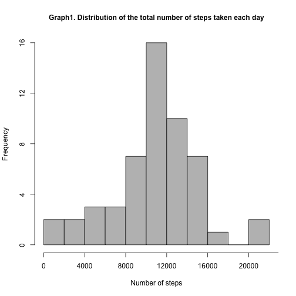

```r
hist(summary1$steps, breaks = 10,
     main = "Graph1. Distribution of the total number of steps taken each day",
     xlab = "Number of steps",
     axes = FALSE,
     col = "grey", cex.main = 1)
axis(1, at = c(0, 4000, 8000, 12000, 16000, 20000, 24000))
axis(2, at = c(0, 4, 8, 12, 16))
```

The following table shows the median and the mean values:

```r
summary(round(summary1$steps))
```

```
##    Min. 1st Qu.  Median    Mean 3rd Qu.    Max.
##      41    8841   10760   10770   13290   21190
```

##What is the average daily activity pattern?

Summary2 presents the aggregation of the average number of steps in the 5min-interval of the day. The data is processed in order to be plot.

```r
library(lubridate)
summary2 <- aggregate(steps ~ interval, activity1, FUN = "mean")
summary2$steps <- round(summary2$steps)
summary2$interval <- paste("0000-01-01", paste(summary2$interval, sep = ":"), sep = " ") #create a POSIXcl columns with the average of the days. The fictitious date 0000-01-01 is added to be able to use a date format
summary2$interval <- ymd_hms(summary2$interval)
```

The plot shows a clear peak at the time 8:35, with the maximum average number of steps measured. There are another smaller peaks at around 12, 16 and 19.

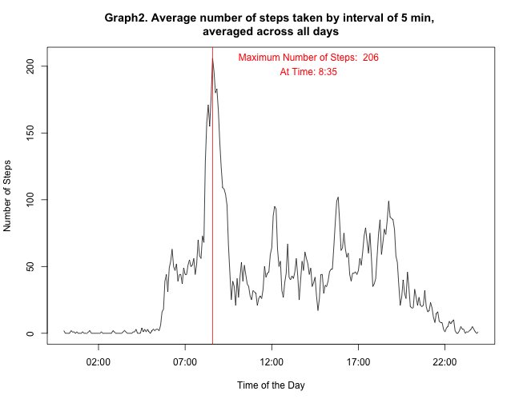

```r
plot(summary2$interval,
     summary2$steps,
     type = "l",
     xlab = "Time of the Day",
     ylab = "Number of Steps")
abline(v = summary2$interval[which.max(summary2$steps)], col = "red")
title("Graph2. Average number of steps taken by interval of 5 min, \naveraged across all days")
text(summary2$interval[which.max(summary2$steps)] + 20000,
     y = summary2$steps[which.max(summary2$steps)] -10,
     labels = paste("At Time:", paste(hour(summary2$interval[which.max(summary2$steps)]),
                                      minute(summary2$interval[which.max(summary2$steps)]),
                                      sep = ":"),
                    sep = " "),
     col = "red")
text(summary2$interval[which.max(summary2$steps)] + 20000,
     y = summary2$steps[which.max(summary2$steps)],
     labels = paste("Maximum Number of Steps: ",
                    max(summary2$steps),
                    sep = " "),
     col = "red")
```

The maximum average number of steps is:

```r
max(summary2$steps)
```

```
## [1] 206
```

recorded at the interval time:

```r
paste(hour(summary2$interval[which.max(summary2$steps)]),
      minute(summary2$interval[which.max(summary2$steps)]),
      sep = ":")
```

```
## [1] "8:35"
```

## Imputing missing values

The total number of values missing in the data is:

```r
length(activity_raw[(is.na(activity_raw$steps)),1])
```

```
## [1] 2304
```

A new dataset is created with the missing values filled with the number of steps taken in each 5min-interval averaged accross all days.

```r
summary3_interval <- aggregate(steps ~ interval, activity1, FUN = "mean") # average of steps per interval accross all days
summary3_interval$steps <- round(summary3_interval$steps)
activity3 <- activity
for(i in 1:length(activity3$steps)) { #across the length of the dateset
      if(is.na(activity3$steps[i])) { #each missing value is replaced
            interval <- activity3$interval[i]
            mean <- summary3_interval[which(summary3_interval$interval == interval),2] #with the average of steps of each 5min-interval
            activity3$steps[i] <- mean
            }
      }
activity3$date <- as.Date(activity3$date.time)
summary3_day <- aggregate(steps ~ date, activity3, FUN = "sum")
```

Make a histogram of the total number of steps taken each day and Calculate and report the mean and median total number of steps taken per day.

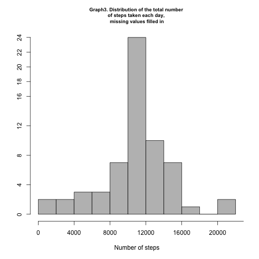

```r
par(mfrow = c(1,1))
hist(summary3_day$steps, breaks = 10,
     cex.main = 0.8,
     main = "Graph3. Distribution of the total number \nof steps taken each day, \nmissing values filled in",
     xlab = "Number of steps",
     ylab = "",
     axes = FALSE,
     ylim = c(0, 24),
     col = "grey")
axis(1, at = c(0, 4000, 8000, 12000, 16000, 20000, 24000))
axis(2, at = c(0, 4, 8, 12, 16, 18, 20, 22, 24))
```

The following tables show the comparison between ignoring or replacing the missing values. The mean and the median values are the same as expected (having added the missing values as mean values), although the distribution is more compact as we can see from the 1st and 3rd quartiles getting closer to the median.

```r
rbind(summary(summary1$steps), summary(summary3_day$steps))
```

```
##      Min. 1st Qu. Median  Mean 3rd Qu.  Max.
## [1,]   41    8841  10760 10770   13290 21190
## [2,]   41    9819  10760 10770   12810 21190
```

From the following graph we note that the only change is an increase in the frequency of the mode. This is predictable as we added average values without adding any relevant information. Therefore the strategy used to replace values is not working

```r
par(mfrow = c(1, 2),
    oma = c(2, 2, 0, 0),
    mar = c(1, 2, 3, 1.5),
    mgp = c(2, 1, 0),
    xpd = NA)

#replotting Graph1
hist(summary1$steps, breaks = 10,
     cex.main = 0.8,
     main = "Graph1. Distribution of the total number \nof steps taken each day, \nmissing values removed",
     xlab = "Number of steps",
     axes = FALSE,
     ylim = c(0, 24),
     col = "grey")
axis(1, at = c(0, 4000, 8000, 12000, 16000, 20000, 24000))
axis(2, at = c(0, 4, 8, 12, 16, 18, 20, 22, 24))
#plotting Graph3 with the filled missing values
hist(summary3_day$steps, breaks = 10,
     cex.main = 0.8,
     main = "Graph3. Distribution of the total number \nof steps taken each day, \nmissing values filled in",
     xlab = "Number of steps",
     ylab = "",
     axes = FALSE,
     ylim = c(0, 24),
     col = "grey")
axis(1, at = c(0, 4000, 8000, 12000, 16000, 20000, 24000))
```

[figure not shown]

## Are there differences in activity patterns between weekdays and weekends?

Create a new factor variable in the dataset with two levels – “weekday” and “weekend” indicating whether a given date is a weekday or weekend day.

```r
library(lubridate)
day_type <- vector(mode = "character", length = length(activity1$steps))
for(i in 1:length(activity1$date.time)) {
      if(weekdays(activity1$date.time[i]) == "Saturday" || weekdays(activity1$date.time[i]) == "Sunday")  { day_type[i] <- "weekend"  }
      else { day_type[i] <- "weekday"   }
      }
activity4 <- cbind(activity1, day_type = as.factor(day_type))
summary4 <- aggregate(steps ~ interval + day_type, activity4, FUN = "mean")
summary4$steps <- round(summary4$steps)
summary4$interval <- paste("0000-01-01", paste(summary4$interval, sep = ":"), sep = " ") #create a POSIXcl columns with the average of the days. The fictitious date 0000-01-01 is added
summary4$interval <- ymd_hms(summary4$interval)
```

Make a panel plot containing a time series plot (i.e. type = “l”) of the 5-minute interval (x-axis) and the average number of steps taken, averaged across all weekday days or weekend days (y-axis).

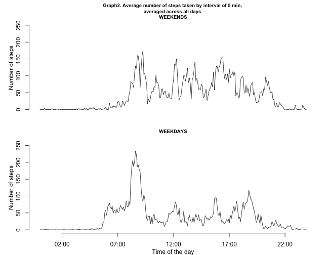

```r
par(mfrow = c(2, 1),
    oma = c(2, 2, 0, 0),
    mar = c(1, 2, 3, 1.5),
    mgp = c(2, 1, 0),
    xpd = NA)
#plot above WEEKEND
plot(summary4$interval[summary4$day_type == "weekend"],
     summary4$steps[summary4$day_type == "weekend"],
     axes = FALSE,
     type = "l",
     xlab = "",
     ylab = "Number of steps",
     ylim = c(0, 250),
     cex.main = 0.8,
     main = "Graph2. Average number of steps taken by interval of 5 min, \naveraged across all days \nWEEKENDS"
     )

axis(2, at = c(0,50, 100, 150, 200, 250))
#plot below WEEKDAY
plot(summary4$interval[summary4$day_type == "weekday"],
     summary4$steps[summary4$day_type == "weekday"],
     axes = FALSE,
     type = "l",
     xlab = "Time of the day",
     ylab = "Number of steps",
     ylim = c(0, 250),
     cex.main = 0.8,
     main = "WEEKDAYS")

axis.POSIXct(x = summary4$interval[summary4$day_type == "weekday"], side = 1)
axis(2, at = c(0,50, 100, 150, 200, 250))
```

During the weekdays the average number of steps is concentrated in the morning and during the day there is relativly less activity and with less variance. During weekends the activity is slightly shifted to the right by about an hour and half, meaning the activity during the day happens later. The peak in the morning is less pronounced but the average during the rest of the day is higher and with higher variance. The following table shows a summary of the of the steps across all intervals and days by Weekdays/Weekends

```r
tapply(summary4$steps, summary4$day_type,
       function(x) {
             c(MINIMUM = round(min(x)),
               MEAN = round(mean(x)),
               MEDIAN = round(median(x)),
               MAXIMUM = round(max(x)),
               STANDARD.DEVIATION = round(sd(x), digits = 2),
               COEFF.VARIATION = round((sd(x)/mean(x)), digits = 2)
               )
             }
       )
```

```
## $weekday
##            MINIMUM               MEAN             MEDIAN
##               0.00              35.00              24.00
##            MAXIMUM STANDARD.DEVIATION    COEFF.VARIATION
##             234.00              42.26               1.20
##
## $weekend
##            MINIMUM               MEAN             MEDIAN
##               0.00              43.00              32.00
##            MAXIMUM STANDARD.DEVIATION    COEFF.VARIATION
##             175.00              44.41               1.03
```